# Worksheet 6

2023-03-02

Questions are below. My solutions are below all the question parts for a question; scroll down if you get stuck. There might be extra discussion below that for some of the questions; you might find that interesting to read, maybe after tutorial.

For these worksheets, you will learn the most by spending a few minutes thinking about how you would answer each question before you look at my solution. There are no grades attached to these worksheets, so feel free to guess: it makes no difference at all how wrong your initial guess is!

# 1 Fuel efficiency comparison

Some cars have on-board computers that calculate quantities related to the car’s performance. One of the things measured is the fuel efficiency, that is, how much gasoline the car uses. On an American car, this is measured in miles per (US) gallon. On one type of vehicle equipped with such a computer, the fuel efficiency was measured each time the gas tank was filled up, and the computer was then reset. Twenty observations were made, and are in http://ritsokiguess.site/datafiles/mpgcomparison.txt. The computer’s values are in the column `Computer`. The driver also calculated the fuel efficiency by hand, by noting the number of miles driven between fill-ups, and the number of gallons of gas required to fill the tank each time. The driver’s values are in `Driver`. The final column `Diff` is the difference between the computer’s value and the driver’s value for each fill-up. The data values are separated by *tabs*.

1. Read in and display (some of) the data.
2. What is it that makes this paired data? Explain briefly.
3. Draw a suitable graph of these data, bearing in mind what you might want to learn from your graph.
4. Is there any difference between the average results of the driver and the computer? (Average could be mean or median, whichever you think is best). Do an appropriate test.
5. The people who designed the car’s computer are interested in whether the values calculated by the computer and by the driver on the same fill-up are *usually* close together. Explain briefly why it is that looking at the average (mean or median) difference is not enough. Describe what you would look at in addition, and how that would help.

My solutions

Some cars have on-board computers that calculate quantities related to the car’s performance. One of the things measured is the fuel efficiency, that is, how much gasoline the car uses. On an American car, this is measured in miles per (US) gallon. On one type of vehicle equipped with such a computer, the fuel efficiency was measured each time the gas tank was filled up, and the computer was then reset. Twenty observations were made, and are in http://ritsokiguess.site/datafiles/mpgcomparison.txt. The computer’s values are in the column `Computer`. The driver also calculated the fuel efficiency by hand, by noting the number of miles driven between fill-ups, and the number of gallons of gas required to fill the tank each time. The driver’s values are in `Driver`. The final column `Diff` is the difference between the computer’s value and the driver’s value for each fill-up. The data values are separated by *tabs*.

1. Read in and display (some of) the data.

Solution

```r
library(tidyverse)
```

This is like the athletes data, so `read_tsv`:

```r
my_url <- "http://ritsokiguess.site/datafiles/mpgcomparison.txt"
fuel <- read_tsv(my_url)
fuel
```

| Fill-up | Computer | Driver | Diff |
| --- | --- | --- | --- |
| 1 | 41.5 | 36.5 | 5.0 |
| 2 | 50.7 | 44.2 | 6.5 |
| 3 | 36.6 | 37.2 | -0.6 |
| 4 | 37.3 | 35.6 | 1.7 |
| 5 | 34.2 | 30.5 | 3.7 |
| 6 | 45.0 | 40.5 | 4.5 |
| 7 | 48.0 | 40.0 | 8.0 |
| 8 | 43.2 | 41.0 | 2.2 |
| 9 | 47.7 | 42.8 | 4.9 |
| 10 | 42.2 | 39.2 | 3.0 |

[output cut: 10 more lines]

20 observations, with columns as promised. The first column `Fill-up` labels the fill-ups from 1 to 20, in case we needed to identify them. (This is an additional clue that we have paired data, or repeated measures in general.[^1])

$\blacksquare$

2. What is it that makes this paired data? Explain briefly.

Solution

There are two measurements for each fill-up: the computer’s calculation of gas mileage, and the driver’s. These go together because they are two calculations of what is supposed to be the same thing. (Another hint is that we have differences, with the veiled suggestion that they might be useful for something.)

If you want to have a general way of tackling this kind of problem, ask yourself “is there more than one observation of the same thing per individual?” Then go on and talk about what the individuals and observations are *for the data you’re looking at.* In this case, the individuals are fill-ups, and there are two observations per fill-up: one by the driver and one by the computer. Compare this with the children learning to read (from lecture): there were $23+21 = 44$ children altogether (individuals), and each child had *one* reading score, based on the reading method they happened to be assigned to. So these are 44 independent observations, and a two-sample test is the way to go.

Extra: if your individuals have *more than two* measurements each, you can’t shoehorn it into a one-sample model any more, because there are too many differences among[^2] measurements now. These are **repeated measures** data, and the modern way to analyze these is using [mixed models](https://m-clark.github.io/mixed-models-with-R/random_intercepts.html). The student GPA example in the link shows how it goes; this is repeated measures because we have *six* observations (of GPA) for each individual (student).

$\blacksquare$

3. Draw a suitable graph of these data, bearing in mind what you might want to learn from your graph.

Solution

In a matched pairs situation, what matters is whether the *differences* have enough of a normal distribution. The separate distributions of the computer’s and driver’s results are of no importance. So make a graph of the differences. We are specifically interested in normality, so a normal quantile plot is best:

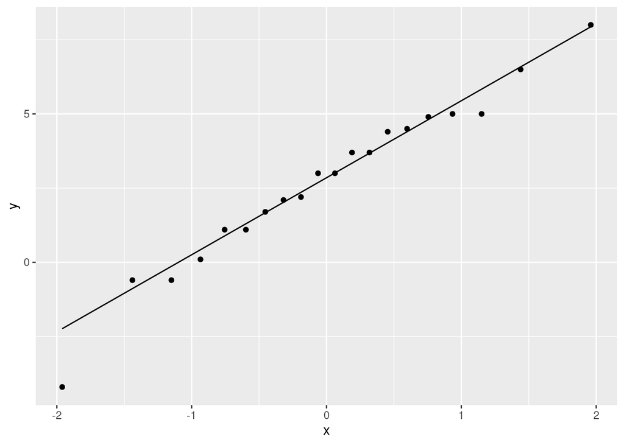

```r
ggplot(fuel, aes(sample = Diff)) + stat_qq() + stat_qq_line()
```

The next best plot is a histogram of the differences:

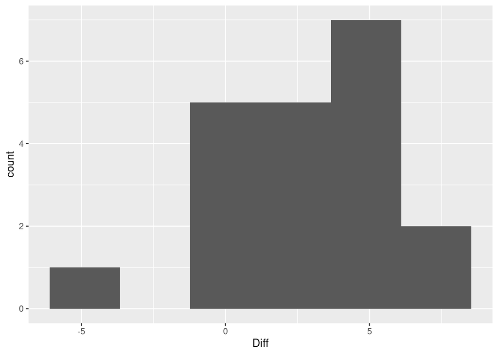

```r
ggplot(fuel, aes(x = Diff)) + geom_histogram(bins = 6)
```

This one actually looks left-skewed, or has an outlier at the bottom. The appearance may very well depend on the number of bins you choose.

Extra: the distributions of the computer’s and driver’s gas mileage measurements themselves are totally irrelevant to whether you would run a matched pairs test of any kind; the only thing that matters is the distribution of the differences.

The only other graph you could justify (and even then it is a bit of a stretch) would be a scatterplot of the two measurements at each fill-up:

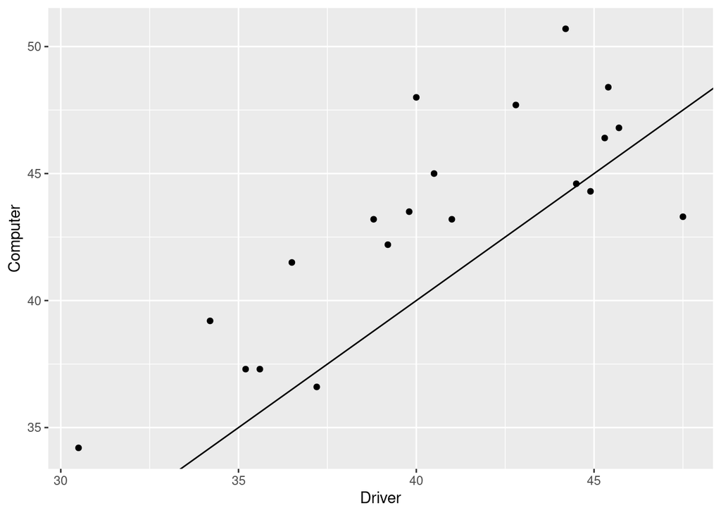

```r
ggplot(fuel, aes(x = Driver, y = Computer)) + geom_point() +
  geom_abline(intercept = 0, slope = 1)
```

By adding the line $y = x$ (which has intercept 0 and slope 1) to the graph, you can see how the pairs of measurements compare to each other; for most of them, the computer’s measurement is larger than the corresponding driver’s measurement (the point is above the line), and for only a few is it smaller. If you had decided to do a matched-pairs sign test, this graph would be interesting (with the line), because the sign test is based on how many points are above the line vs. how many are bolew. But what this graph *does not* do is tell you whether you need to do a matched-paris sign test in the first place, becasue it does not tell you about the distribution of the differences (in particular, whether that is normal enough). Thus, the scatterplot, even with the line, is inferior to even the histogram of differences.

$\blacksquare$

4. Is there any difference between the average results of the driver and the computer? (Average could be mean or median, whichever you think is best). Do an appropriate test.

Solution

The choices are a matched-pairs $t$-test, or a matched-pairs sign test (on the differences). To choose between those, look back at your graph. My take is that the only possible problem is the smallest (most negative) difference, but that is not very much smaller than expected. This is especially so given the sample size (20), which means that the Central Limit Theorem will help us enough to take care of the small outlier.

I think, therefore, that a paired $t$-test is the way to go, to test the null that the mean difference is zero (against the two-sided alternative that it is not zero, since we were looking for *any* difference). There are two ways you could do this: as literal matched pairs:

```r
with(fuel, t.test(Computer, Driver, paired = TRUE))
```

```
##
##  Paired t-test
##
## data:  Computer and Driver
## t = 4.358, df = 19, p-value = 0.0003386
## alternative hypothesis: true mean difference is not equal to 0
## 95 percent confidence interval:
##  1.418847 4.041153
## sample estimates:
## mean difference
##            2.73
```

or, as a one-sample test on the differences:

```r
with(fuel, t.test(Diff, mu = 0))
```

```
##
##  One Sample t-test
##
## data:  Diff
## t = 4.358, df = 19, p-value = 0.0003386
## alternative hypothesis: true mean is not equal to 0
## 95 percent confidence interval:
##  1.418847 4.041153
## sample estimates:
## mean of x
##      2.73
```

with the same result.

If you thought that low value was too much of an outlier, the right thing would have been a sign test that the *median* difference is zero (vs. not zero), thus (using the `smmr` package):

```r
sign_test(fuel, Diff, 0)
```

```
## $above_below
## below above
##     3    17
##
## $p_values
##   alternative     p_value
## 1       lower 0.999798775
## 2       upper 0.001288414
## 3   two-sided 0.002576828
```

In any of those cases, we conclude that the average difference is *not* zero, since the P-values are less than 0.05. (The right one for the sign test is 0.0026.)

I don’t mind which test you do, as long as it is one of the ways of doing matched pairs, and you *justify your choice* by going back to your graph. Doing one of the tests *without saying why* is being a STAB57-level statistician (in fact, it may not even be that), not a professional-level applied statistician.

Extra: the way you tell whether the sample size really is large enough to overcome that low outlier, if indeed that is what it is, is the usual thing: a bootstrap sampling distribution, but of the *differences*. Now that we know about the normal quantile plot, this is the way to plot this distribution as well (“is it normal?” is the question we want the answer to):

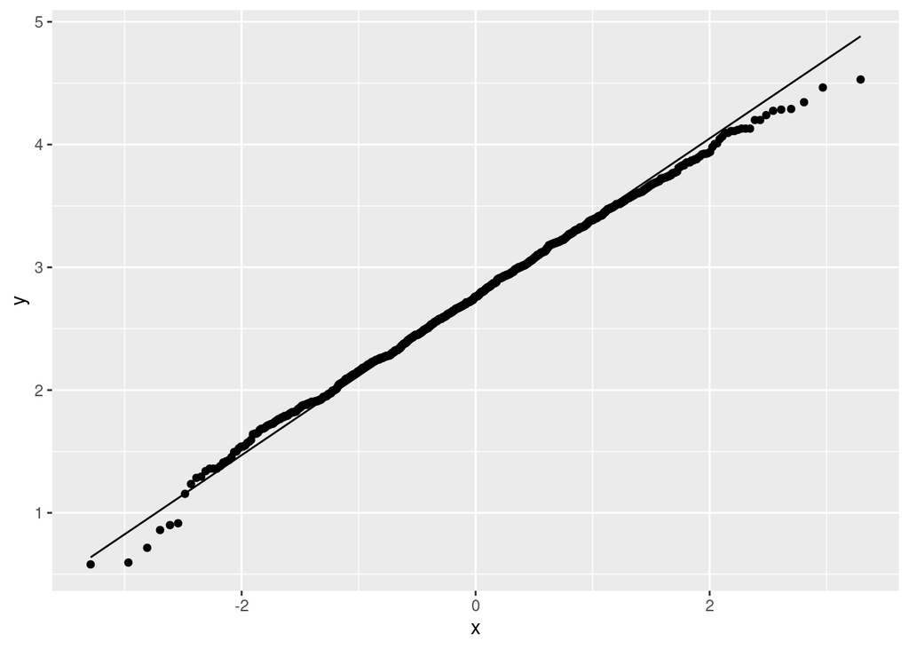

```r
tibble(sim = 1:1000) %>%
  rowwise() %>%
  mutate(my_sample = list(sample(fuel$Diff, replace = TRUE))) %>%
  mutate(my_mean = mean(my_sample)) %>%
  ggplot(aes(sample = my_mean)) + stat_qq() + stat_qq_line()
```

This is the tiniest bit skewed left (as a result of that low outlier),[^3] but I think it’s fair to say that the points are all close to the line and therefore that normality (and the matched-pairs $t$-test) are just fine. Another thing to say here is that this tiny deviation from normality is something you would have a hard time seeing on a histogram. I could re-do the simulation exactly (I set the same random number seed each time) but finish by drawing a histogram to demonstrate this:

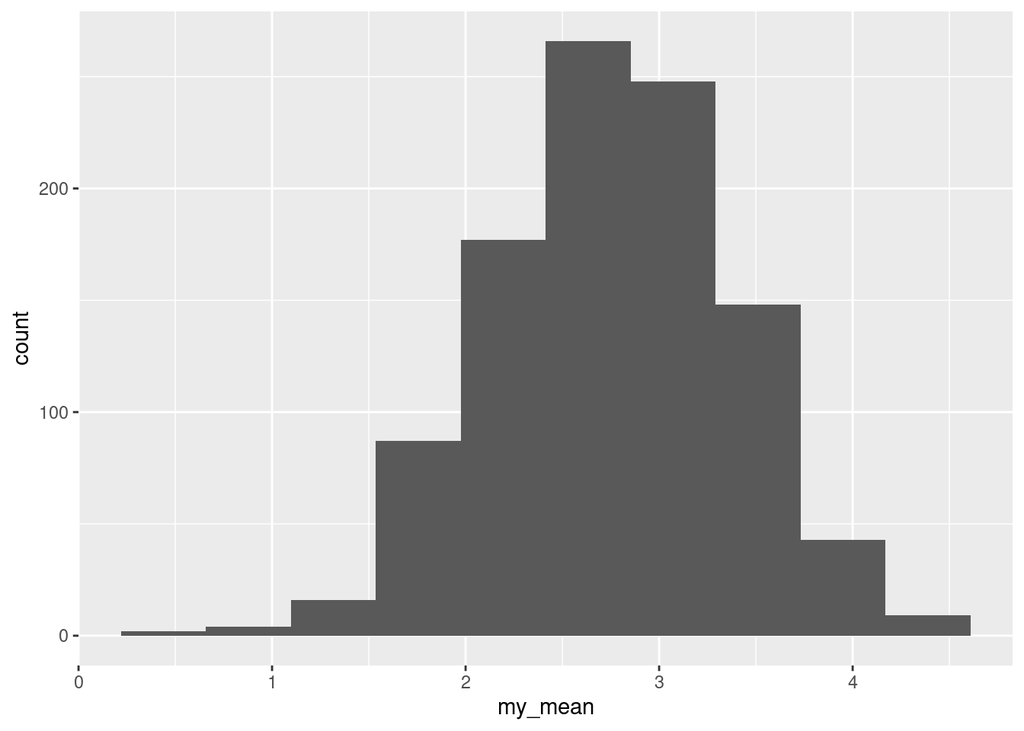

```r
tibble(sim = 1:1000) %>%
  rowwise() %>%
  mutate(my_sample = list(sample(fuel$Diff, replace = TRUE))) %>%
  mutate(my_mean = mean(my_sample)) %>%
  ggplot(aes(x = my_mean)) + geom_histogram(bins = 10)
```

Are those few observations in the two lowest bins (1 or below) an indication of non-normality, or just chance? I actually think it’s just chance, because if you do the simulation again with a different seed, you may end up not seeing any problems with normality at all. (Or do it with 10,000 simulations instead of 1000.)

$\blacksquare$

5. The people who designed the car’s computer are interested in whether the values calculated by the computer and by the driver on the same fill-up are *usually* close together. Explain briefly why it is that looking at the average (mean or median) difference is not enough. Describe what you would look at in addition, and how that would help.

Solution

The mean (or median) difference can be close to zero without the individual differences being close to zero. The driver could be sometimes way higher and sometimes way lower, and the average difference could come out close to zero, even though each individual pair of measurements is not that close together. Thus looking only at the average difference is not enough.

There are (at least) two (related) things you might choose from to look at, in addition to the mean or median:

- the *spread* of the differences (the SD or inter-quartile range). If the average difference *and* the spread of differences are both close to zero, that would mean that the driver’s and computer’s values are *consistently* similar.
- a suitable confidence interval here (for the mean or median difference, as appropriate for what you did) would also get at this point.

To think about the spread: use the SD if you did the $t$-test for the mean, and use the IQR if you did the sign test for the median, that is, one of these:

```r
fuel %>% summarize(diff_sd = sd(Diff))
```

| diff_sd |
| --- |
| 2.801522 |

or

```r
fuel %>% summarize(diff_iqr = IQR(Diff))
```

| diff_iqr |
| --- |
| 3.5 |

as appropriate. Make a call about whether you think your measure of spread is small or large. If you think it’s small, you can say that the differences are consistent with each other, and therefore that the computer’s and driver’s values are typically different by about the same amount (we concluded that they *are* different). If you think your measure of spread is large, then the driver’s and computer’s values are inconsistently different from each other (which would be bad news for the people who designed the car’s computer, as long as you think the driver was being reasonably careful in their record-keeping).

If you said that the confidence interval for the mean/median was the thing to look at, then pull the interval out of the $t$-test output or run `ci_median`, as appropriate. The computer’s miles per gallon is consistently between 1.4 and 4.0 miles per gallon higher (mean) or 1.1 and 4.5 miles per gallon higher (median). Make a call about whether you consider this interval short or long, bearing in mind it’s based on the difference between two numbers that are about 40, and then say that the computer’s measurement is larger than the driver’s by a consistent amount (if you think the interval is short) or by an amount that varies quite a bit (if you think the interval is long).

$\blacksquare$

[^1]: If we had 40 independent miles-per-gallon measurements, there would be no reason to have the `Fill-up` column, because there would be no basis to link a Computer value with a particular Driver one.
[^2]: To be precise linguistically, there are “differences between” two things, as in matched pairs, and “differences among” three or more things, as in ANOVA.
[^3]: I got this sort of shape the first time, but I had to try several random number seeds to get it to come up again.